# Human Action Recognition

Haili DENG

August 18, 2015

# Part I: Data Loading and Cleansing

## 0. Register multi-core processing:

In my case, it’s 8-core.

```r
require(doParallel)
registerDoParallel(cores=8)
```

## 1. Download and read raw data files:

```r
filePath1<-paste0(getwd(),"/pml-training.csv")
filePath2<-paste0(getwd(),"/pml-testing.csv")
if (!file.exists(filePath1)){
    fileURL<-"http://d396qusza40orc.cloudfront.net/predmachlearn/pml-training.csv"
    download.file(fileURL,destfile = filePath1)
    rm(fileURL)
    }
if(!file.exists(filePath2)){
    fileURL<-"http://d396qusza40orc.cloudfront.net/predmachlearn/pml-testing.csv"
    download.file(fileURL,destfile = filePath2)
    rm(fileURL)
    }
if (!exists("RawData")) RawData<-read.csv(filePath1)
if (!exists("TestData")) TestData<-read.csv(filePath2)
rm(filePath1,filePath2)
```

## 2. Data cleaning

Remove columns with NAs and bookeeping entries that have no predictive value. By inspection the header of RawData, we pick out and store the relevant colnames name to vector *keep*

```r
data.cleaning<-function(x,classe=TRUE){
    keep<-c("user_name","roll_belt","pitch_belt","yaw_belt","total_accel_belt","gyros_belt_x","gyros_belt_y","gyros_belt_z","accel_belt_x","accel_belt_y","accel_belt_z","magnet_belt_x","magnet_belt_y","magnet_belt_z","roll_arm","pitch_arm","yaw_arm","total_accel_arm","gyros_arm_x","gyros_arm_y","gyros_arm_z","accel_arm_x","accel_arm_y","accel_arm_z","magnet_arm_x","magnet_arm_y","magnet_arm_z","roll_dumbbell","pitch_dumbbell","yaw_dumbbell","total_accel_dumbbell","gyros_dumbbell_x","gyros_dumbbell_y","gyros_dumbbell_z","accel_dumbbell_x","accel_dumbbell_y","accel_dumbbell_z","magnet_dumbbell_x","magnet_dumbbell_y","magnet_dumbbell_z","roll_forearm","pitch_forearm","yaw_forearm","total_accel_forearm","gyros_forearm_x","gyros_forearm_y","gyros_forearm_z","accel_forearm_x","accel_forearm_y","accel_forearm_z","magnet_forearm_x","magnet_forearm_y","magnet_forearm_z","classe")
    if (!classe) keep<-keep[1:53]
    return(x[keep])
}
CleanedData<-data.cleaning(RawData,classe=TRUE)
```

# Part II: Data exploration and model selection

## 3. Data slicing

The dataset is generated by 6 participants:**adelmo, carlitos, charles, eurico, jeremy, pedro**, and they might show different features even for the same class of action. Therefore, it make sense to sub-divide the dataset into six group.

```r
participant<-levels(CleanedData$user_name)
for (i in 1:6){
    temp<-CleanedData[CleanedData$user_name==participant[i],2:54]
    assign(participant[i],temp)
}
rm(temp,i)
```

## 4. Exploratory Analysis

First we compared two dataset generated by adelmo and pedro(one have the most observation and another the least.)

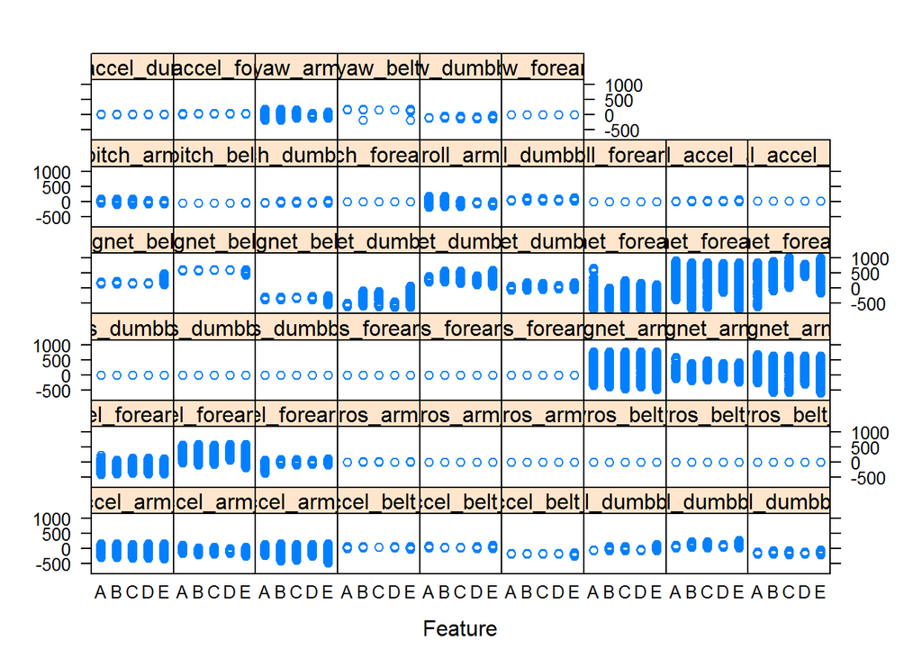

```r
require(caret)
featurePlot(x=adelmo[,2:52],y=adelmo$classe)
```

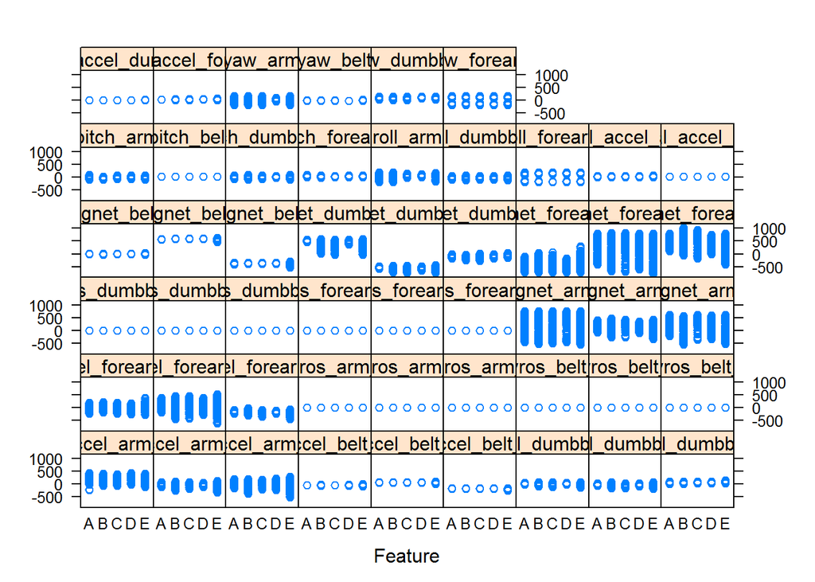

```r
featurePlot(x=pedro[,2:52],y=pedro$classe)
```

We can Observe that the predictors are not center and scale properly. Some predictors might have zero variability, therefore we perform a test and remove the relevant column.

```r
nearZeroVar(adelmo)
```

```
## [1] 40 41 42
```

```r
nearZeroVar(carlitos)
```

```
## integer(0)
```

```r
nearZeroVar(charles)
```

```
## integer(0)
```

```r
nearZeroVar(eurico)
```

```
## integer(0)
```

```r
nearZeroVar(jeremy)
```

```
## [1] 14 15 16
```

```r
nearZeroVar(pedro)
```

```
## integer(0)
```

```r
adelmo<-adelmo[,-nearZeroVar(adelmo)]
jeremy<-jeremy[,-nearZeroVar(jeremy)]
```

## 5. Model Selection

Try out different model and assess their performance with subset pedro.

```r
require(randomForest)
inBuild<-createDataPartition(y=pedro$classe,p=0.8,list=FALSE)
pedro_training<-pedro[inBuild,]
# Creat cross-validation subset
pedro_X_validation<-pedro[-inBuild,]
# Creat training and testing subset
inTrain_sub<-createDataPartition(y=pedro_training$classe,p=0.75,list=FALSE)
pedro_testing_sub<-pedro_training[-inTrain_sub,]
pedro_training_sub<-pedro_training[inTrain_sub,]
# Random Forest
RfFit<-randomForest(classe~.,data=pedro_training_sub,preProcess=c("center","scale"))
Rf_pred<-predict(RfFit,pedro_testing_sub)
Rf_val_pred<-predict(RfFit,pedro_X_validation)
confusionMatrix(pedro_testing_sub$classe,Rf_pred)
```

```
## Confusion Matrix and Statistics
##
##           Reference
## Prediction   A   B   C   D   E
##          A 128   0   0   0   0
##          B   2  99   0   0   0
##          C   0   0 100   0   0
##          D   0   0   1  93   0
##          E   0   0   0   0  99
##
## Overall Statistics
##
##                Accuracy : 0.9943
##                  95% CI : (0.9833, 0.9988)
##     No Information Rate : 0.249
##     P-Value [Acc > NIR] : < 2.2e-16
##
##                   Kappa : 0.9928
##  Mcnemar's Test P-Value : NA
##
## Statistics by Class:
##
##                      Class: A Class: B Class: C Class: D Class: E
## Sensitivity            0.9846   1.0000   0.9901   1.0000   1.0000
## Specificity            1.0000   0.9953   1.0000   0.9977   1.0000
## Pos Pred Value         1.0000   0.9802   1.0000   0.9894   1.0000
## Neg Pred Value         0.9949   1.0000   0.9976   1.0000   1.0000
## Prevalence             0.2490   0.1897   0.1935   0.1782   0.1897
## Detection Rate         0.2452   0.1897   0.1916   0.1782   0.1897
## Detection Prevalence   0.2452   0.1935   0.1916   0.1801   0.1897
## Balanced Accuracy      0.9923   0.9976   0.9950   0.9988   1.0000
```

```r
varImpPlot(RfFit)
# Bagging
treebag <- bag(x=pedro_training_sub[,1:52],y=pedro_training_sub$classe, B = 20,bagControl = bagControl(fit = ctreeBag$fit,predict = ctreeBag$pred,aggregate = ctreeBag$aggregate),preProcess=c("center","scale"))
treebag_pred<-predict(treebag,pedro_testing_sub)
confusionMatrix(pedro_testing_sub$classe,treebag_pred)
```

```
## Confusion Matrix and Statistics
##
##           Reference
## Prediction   A   B   C   D   E
##          A 124   3   0   0   1
##          B   5  96   0   0   0
##          C   3   3  93   1   0
##          D   0   0   3  91   0
##          E   0   0   0   1  98
##
## Overall Statistics
##
##                Accuracy : 0.9617
##                  95% CI : (0.9414, 0.9764)
##     No Information Rate : 0.2529
##     P-Value [Acc > NIR] : < 2.2e-16
##
##                   Kappa : 0.9519
##  Mcnemar's Test P-Value : NA
##
## Statistics by Class:
##
##                      Class: A Class: B Class: C Class: D Class: E
## Sensitivity            0.9394   0.9412   0.9688   0.9785   0.9899
## Specificity            0.9897   0.9881   0.9836   0.9930   0.9976
## Pos Pred Value         0.9688   0.9505   0.9300   0.9681   0.9899
## Neg Pred Value         0.9797   0.9857   0.9929   0.9953   0.9976
## Prevalence             0.2529   0.1954   0.1839   0.1782   0.1897
## Detection Rate         0.2375   0.1839   0.1782   0.1743   0.1877
## Detection Prevalence   0.2452   0.1935   0.1916   0.1801   0.1897
## Balanced Accuracy      0.9646   0.9646   0.9762   0.9858   0.9938
```

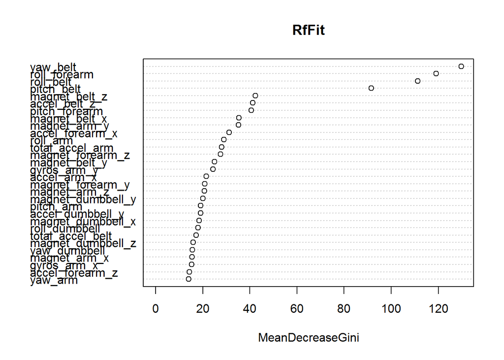

```r
varImpPlot(RfFit)
```

```r
# Boosting
gbmFit<-train(classe~.,method='gbm',data=pedro_training_sub,preProcess=c("center","scale"))
gbm_pred<-predict(gbmFit,pedro_testing_sub)
confusionMatrix(pedro_testing_sub$classe,gbm_pred)
```

```
## Confusion Matrix and Statistics
##
##           Reference
## Prediction   A   B   C   D   E
##          A 128   0   0   0   0
##          B   1 100   0   0   0
##          C   0   0 100   0   0
##          D   0   0   0  94   0
##          E   0   0   0   0  99
##
## Overall Statistics
##
##                Accuracy : 0.9981
##                  95% CI : (0.9894, 1)
##     No Information Rate : 0.2471
##     P-Value [Acc > NIR] : < 2.2e-16
##
##                   Kappa : 0.9976
##  Mcnemar's Test P-Value : NA
##
## Statistics by Class:
##
##                      Class: A Class: B Class: C Class: D Class: E
## Sensitivity            0.9922   1.0000   1.0000   1.0000   1.0000
## Specificity            1.0000   0.9976   1.0000   1.0000   1.0000
## Pos Pred Value         1.0000   0.9901   1.0000   1.0000   1.0000
## Neg Pred Value         0.9975   1.0000   1.0000   1.0000   1.0000
## Prevalence             0.2471   0.1916   0.1916   0.1801   0.1897
## Detection Rate         0.2452   0.1916   0.1916   0.1801   0.1897
## Detection Prevalence   0.2452   0.1935   0.1916   0.1801   0.1897
## Balanced Accuracy      0.9961   0.9988   1.0000   1.0000   1.0000
```

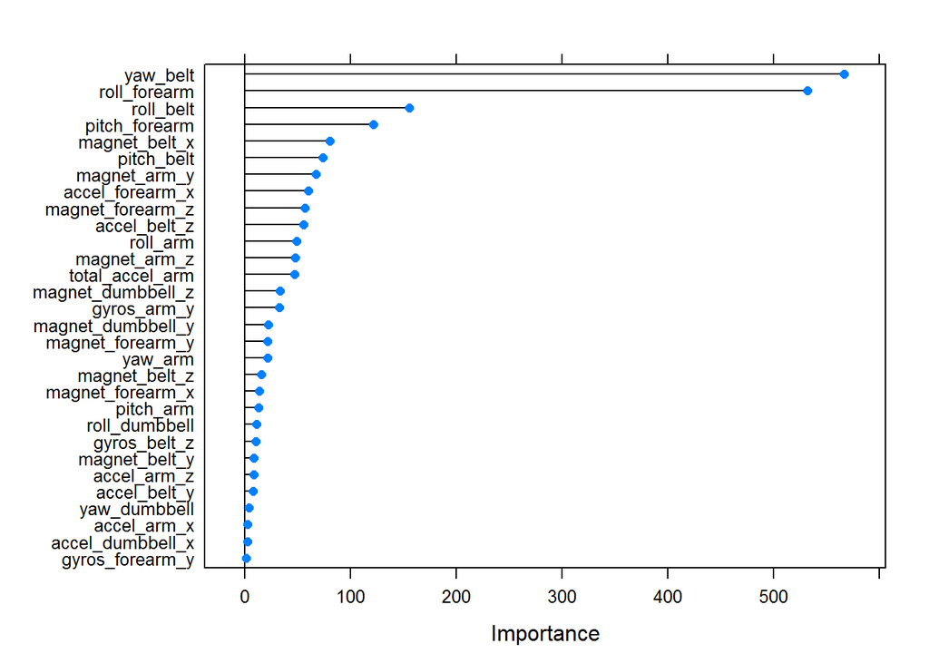

```r
plot(varImp(gbmFit, scale = FALSE),top= 30)
```

```r
# Linear Discriminant Analysis
ldaFit<-train(classe~.,method='lda',data=pedro_training_sub,preProcess=c("center","scale"))
lda_pred<-predict(ldaFit,pedro_testing_sub)
confusionMatrix(pedro_testing_sub$classe,lda_pred)
```

```
## Confusion Matrix and Statistics
##
##           Reference
## Prediction   A   B   C   D   E
##          A 125   0   0   3   0
##          B  15  85   1   0   0
##          C   3   7  88   2   0
##          D   0   1  14  79   0
##          E   3   0   0   1  95
##
## Overall Statistics
##
##                Accuracy : 0.9042
##                  95% CI : (0.8757, 0.9281)
##     No Information Rate : 0.2797
##     P-Value [Acc > NIR] : < 2.2e-16
##
##                   Kappa : 0.8796
##  Mcnemar's Test P-Value : NA
##
## Statistics by Class:
##
##                      Class: A Class: B Class: C Class: D Class: E
## Sensitivity            0.8562   0.9140   0.8544   0.9294   1.0000
## Specificity            0.9920   0.9627   0.9714   0.9657   0.9906
## Pos Pred Value         0.9766   0.8416   0.8800   0.8404   0.9596
## Neg Pred Value         0.9467   0.9810   0.9645   0.9860   1.0000
## Prevalence             0.2797   0.1782   0.1973   0.1628   0.1820
## Detection Rate         0.2395   0.1628   0.1686   0.1513   0.1820
## Detection Prevalence   0.2452   0.1935   0.1916   0.1801   0.1897
## Balanced Accuracy      0.9241   0.9383   0.9129   0.9475   0.9953
```

```r
confusionMatrix(pedro_X_validation$classe,Rf_val_pred)
```

```
## Confusion Matrix and Statistics
##
##           Reference
## Prediction   A   B   C   D   E
##          A 128   0   0   0   0
##          B   1 100   0   0   0
##          C   0   0  99   0   0
##          D   0   0   1  92   0
##          E   0   0   0   0  99
##
## Overall Statistics
##
##                Accuracy : 0.9962
##                  95% CI : (0.9862, 0.9995)
##     No Information Rate : 0.2481
##     P-Value [Acc > NIR] : < 2.2e-16
##
##                   Kappa : 0.9952
##  Mcnemar's Test P-Value : NA
##
## Statistics by Class:
##
##                      Class: A Class: B Class: C Class: D Class: E
## Sensitivity            0.9922   1.0000   0.9900   1.0000   1.0000
## Specificity            1.0000   0.9976   1.0000   0.9977   1.0000
## Pos Pred Value         1.0000   0.9901   1.0000   0.9892   1.0000
## Neg Pred Value         0.9974   1.0000   0.9976   1.0000   1.0000
## Prevalence             0.2481   0.1923   0.1923   0.1769   0.1904
## Detection Rate         0.2462   0.1923   0.1904   0.1769   0.1904
## Detection Prevalence   0.2462   0.1942   0.1904   0.1788   0.1904
## Balanced Accuracy      0.9961   0.9988   0.9950   0.9988   1.0000
```

```r
get.answers<-function(x,y=TestData){
    require(randomForest)
    RfFit<-randomForest(classe~.,data=x,preProcess=c("center","scale"))
    answers<-predict(RfFit,TestData[y$user_name==deparse(substitute(x)),])
    return(answers)
}
```